# IE 582 Project

Erhan Can Ozcan-Elif Konyar-Burakhan Sel

1/6/2019

# 1) Introduction

Predicting the outcome of the soccer games in the Premier League is the purpose of this study. The data that we worked on is providing us information about the match results and bookmakers odds of the old games. By using this information, we tried to achieve the best predictions of the match result probabilities. While submitting probabilities during 8 rounds, we continued to adapt our models and methods.

# 2) Methodology

We started to work on the data by feature extraction and tried to add many features that are meaningful to us. At the end of this process, we got 313 features. Some of them were match results related features, others were odd related features. By using these features, we constructed models and selected parameters with the help of the cross-validation technique. To do that, the 2018-2019 season is separated to use as test data while old data is used as training data. Also, mean rps value is used as a performance measure. After constructing various models, we observed that the models are providing us approximately the same results and none of them is outperforming others. This conclusion led us to decrease the number of features and to find the most meaningful ones between them to prevent complexity. Therefore, we eliminated some of the features using random forests’ mean decrease Gini value and ended up with 100 features. Finally, we were able to construct models and interpret them with the knowledge of the previously constructed models. We learned from the trials of the models with 313 features, the decision tree was generally good to use because of its simplicity and good results. Thus, we decided to utilize decision tree firstly. Although the decision tree model was good, in some leaves we didn’t observe good rps values. Therefore we adapt our prediction method in such a way that in the case of our test data goes into the unsuccessful leaves, we alternate the model and use logistic regression.

## 2.1) Feature Extraction

Good predictions depend on meaningful predictors as much as depending on wisely chosen models. To make our soccer games predictions better, instead of relying only on the bookmakers’ announced odd data, we can also benefit from team-specific statistics.

### 2.1.1) Match Results Related Features

While obtaining Match Result related features, all of the matches played in the first 5 weeks of the season are ignored. This is due to not having enough observations to obtain features such as number of home wins in last 5 matches etc.

```r
#dir()
setwd("/Users/elifkonyar/Desktop/Proje Son")

#read data
league_matches_raw<- readRDS("df9b1196-e3cf-4cc7-9159-f236fe738215_matches.rds")



#Data manupilation to get the number of goals for each team.
league_matches_raw[,score_updated:=(gsub("\\D", "", league_matches_raw$score))]
home_score_tmp<-substring(league_matches_raw$score_updated,1,1)
league_matches_raw$home_score<-home_score_tmp
league_matches_raw$home_score<-as.numeric(league_matches_raw$home_score)
rm(home_score_tmp)
away_score_tmp<-substring(league_matches_raw$score_updated,2)
league_matches_raw$away_score<-away_score_tmp
league_matches_raw$away_score<-as.numeric(league_matches_raw$away_score)
rm(away_score_tmp)
#the process of learning number of goals has finished.



# result_explanation ------------------------------------------------------
league_matches_raw[,result:=ifelse(home_score>away_score,1,(ifelse(home_score==away_score,0,2)))]
#we can learn the final result of matches. Note that;
#               1 represents home win
#               0 represents draw
#               2 represents away win.

# end-------------------


# time_transformations ----------------------------------------------------

#adjusting the date column in the data.
league_matches_raw[,time_stamp:=anytime(date)]

#the below data table, matchId_score will be combined with other data set.
league_matches_raw<-league_matches_raw[,.(matchId,home,away,home_score,away_score,result,time_stamp)]
league_matches_raw<-league_matches_raw[order(time_stamp)]


league_matches_raw[,year:=year(time_stamp)]
league_matches_raw[,month:=month(time_stamp)]
league_matches_raw[,year2:=ifelse(month>=8,year+1,year)]
league_matches_raw[,year:=ifelse(month<8,year2-1,year)]

#year: denotes in which year the season begins.
#year2: denotes in which year the season ends.
# end -------------

no_of_row <- nrow(league_matches_raw)


number_of_teams_in_league <- 20
#through the operations below, "selected_year_league_matches_up" is obtained.
#in that table for year 2010, we can see that which game is played by home and away team.
#note that some shifts could be observed in the schedule. For example, while home team plays
#its 15th match, away team can play its 16th match.

# selectyear_and_find_matchno_for_homeandaway -----------------------------

focused_year=2011
add_selected_year<-function(focused_year,data){
  selected_year_league_matches<-league_matches_raw[year==focused_year]

  if(focused_year==2018){
    selected_year_league_matches<-unique(selected_year_league_matches)
    selected_year_league_matches[,home:=ifelse(home=="manchester-utd","manchester-united",home)]
    selected_year_league_matches[,away:=ifelse(away=="manchester-utd","manchester-united",away)]
  }
  if(focused_year==2017){
    selected_year_league_matches[,home:=ifelse(home=="newcastle","newcastle utd",home)]
    selected_year_league_matches[,home:=ifelse(home=="stoke","stoke city",home)]
    selected_year_league_matches[,away:=ifelse(away=="newcastle","newcastle utd",away)]
    selected_year_league_matches[,away:=ifelse(away=="stoke","stoke city",away)]
  }

  #team name control
  kontrol1<-selected_year_league_matches[,.(.N),keyby=.(home)]
  kontrol2<-selected_year_league_matches[,.(.N),keyby=.(away)]
  if (nrow(kontrol1)!=20 || nrow(kontrol2)!=20){
    paste0("error in the team names in year ", focused_year, "check tables kontrol1 and kontrol2 in the function")
  }
  #team name control end
  selected_year_league_matches_copy=selected_year_league_matches
  selected_year_league_matches_copy[,home:=away]
  selected_year_league_matches<-league_matches_raw[year==focused_year]
  if(focused_year==2018){
    selected_year_league_matches<-unique(selected_year_league_matches)
    selected_year_league_matches[,home:=ifelse(home=="manchester-utd","manchester-united",home)]
    selected_year_league_matches[,away:=ifelse(away=="manchester-utd","manchester-united",away)]
  }
  if(focused_year==2017){
    selected_year_league_matches[,home:=ifelse(home=="newcastle","newcastle utd",home)]
    selected_year_league_matches[,home:=ifelse(home=="stoke","stoke city",home)]
    selected_year_league_matches[,away:=ifelse(away=="newcastle","newcastle utd",away)]
    selected_year_league_matches[,away:=ifelse(away=="stoke","stoke city",away)]
  }
  selected_year_league_matches_tmp<-rbind(selected_year_league_matches,selected_year_league_matches_copy)
  selected_year_league_matches_tmp<-selected_year_league_matches_tmp[order(home,time_stamp)]

  #selected_year_league_matches_tmp[,nth_game:=rleid(time_stamp),by=list(home)]


  selected_year_league_matches_tmp[,nth_game:=rleid(time_stamp),by=list(home)]

  selected_year_league_matches_up<-left_join(selected_year_league_matches,selected_year_league_matches_tmp,by=c("home"="home","time_stamp"="time_stamp"))
  selected_year_league_matches_up<-as.data.table(selected_year_league_matches_up)
  selected_year_league_matches_up<-selected_year_league_matches_up[,.(matchId=matchId.x,home,away=away.x,home_score=home_score.x,away_score=away_score.y,result=result.x,time_stamp,year=year.x,month=month.x,year2=year2.x,home_nth_game=nth_game)]

  selected_year_league_matches_up<-selected_year_league_matches_up[order(matchId)]


  selected_year_league_matches<-league_matches_raw[year==focused_year]

  if(focused_year==2018){
    selected_year_league_matches<-unique(selected_year_league_matches)
    selected_year_league_matches[,home:=ifelse(home=="manchester-utd","manchester-united",home)]
    selected_year_league_matches[,away:=ifelse(away=="manchester-utd","manchester-united",away)]
  }
  if(focused_year==2017){
    selected_year_league_matches[,home:=ifelse(home=="newcastle","newcastle utd",home)]
    selected_year_league_matches[,home:=ifelse(home=="stoke","stoke city",home)]
    selected_year_league_matches[,away:=ifelse(away=="newcastle","newcastle utd",away)]
    selected_year_league_matches[,away:=ifelse(away=="stoke","stoke city",away)]
  }

  selected_year_league_matches_copy=selected_year_league_matches
  selected_year_league_matches_copy[,away:=home]
  selected_year_league_matches<-league_matches_raw[year==focused_year]
  if(focused_year==2018){
    selected_year_league_matches<-unique(selected_year_league_matches)
    selected_year_league_matches[,home:=ifelse(home=="manchester-utd","manchester-united",home)]
    selected_year_league_matches[,away:=ifelse(away=="manchester-utd","manchester-united",away)]
  }
  if(focused_year==2017){
    selected_year_league_matches[,home:=ifelse(home=="newcastle","newcastle utd",home)]
    selected_year_league_matches[,home:=ifelse(home=="stoke","stoke city",home)]
    selected_year_league_matches[,away:=ifelse(away=="newcastle","newcastle utd",away)]
    selected_year_league_matches[,away:=ifelse(away=="stoke","stoke city",away)]
  }
```

```r
  selected_year_league_matches_tmp<-rbind(selected_year_league_matches,selected_year_league_matches_copy)
  selected_year_league_matches_tmp<-selected_year_league_matches_tmp[order(away,time_stamp)]

  selected_year_league_matches_tmp[,nth_game:=rleid(time_stamp),by=list(away)]

  selected_year_league_matches_up_away<-left_join(selected_year_league_matches,selected_year_league_matches_tmp,by=c("away"="away","time_stamp"="time_stamp"))
  selected_year_league_matches_up_away<-as.data.table(selected_year_league_matches_up_away)
  selected_year_league_matches_up_away<-selected_year_league_matches_up_away[,.(matchId=matchId.x,away_nth_game=nth_game)]

  selected_year_league_matches_up_away<-selected_year_league_matches_up_away[order(matchId)]

  #checkpoint
  #sum(selected_year_league_matches_up$matchId==selected_year_league_matches_up_away$matchId)

  selected_year_league_matches_up[,away_nth_game:=selected_year_league_matches_up_away$away_nth_game]
  selected_year_league_matches_up<-selected_year_league_matches_up[order(time_stamp)]

  #end --------


  # extract_variables_for_each_team_FUNCTION -----------------------------------------
  unique_teams<-selected_year_league_matches_up[,.(.N),keyby=.(home)]

  fill_with_each_team<-function(i,particular_team){
    focused_team=unique_teams[i,1]

    selected_home<-selected_year_league_matches_up[home==focused_team]
    selected_home<-selected_home[,c(-12)]
    setnames(selected_home,old=c("home_nth_game","home_score","away_score"),new=c("nth_game", "scored_goal","goals_conceded"))

    selected_away<-selected_year_league_matches_up[away==focused_team]
    selected_away<-selected_away[,-11]
    setnames(selected_away,old=c("away_nth_game","home_score","away_score"),new=c("nth_game", "goals_conceded","scored_goal"))

    selected_team<-rbind(selected_home,selected_away)
    selected_team<-selected_team[order(time_stamp)]


    #till a match how many goals scored by manchester united. Note that we have na in the first match.
    selected_team[,cum_scored_goal:=cumsum(scored_goal)]
    selected_team[,cum_scored_goal:=shift(selected_team$cum_scored_goal)]

    #till a match how many goals conceded by manchester united. Note that we have na in the first match.
    selected_team[,cum_goals_conceded:=cumsum(goals_conceded)]
    selected_team[,cum_goals_conceded:=shift(selected_team$cum_goals_conceded)]
    selected_team[,team:=focused_team]

    #till a match how many points reached by manchester united. Note that we have na in the first match.
    selected_team[,point:=ifelse(scored_goal>goals_conceded,3,0)]
    selected_team[,point:=ifelse(scored_goal==goals_conceded,1,point)]
    selected_team[,point:=cumsum(point)]
    selected_team[,point:=shift(selected_team$point)]

    #previous match how many goals scored. Note that we have na in the first match.
    selected_team[,prev_scored:=scored_goal]
    selected_team[,prev_scored:=shift(selected_team$prev_scored)]

    #previous match how many goals conceded Note that we have na in the first match.
    selected_team[,prev_conceded:=goals_conceded]
    selected_team[,prev_conceded:=shift(selected_team$prev_conceded)]

    #is_home-is_away
    selected_team[,is_home:=ifelse(home==team,1,0)]
    selected_team[,is_away:=ifelse(away==team,1,0)]
    #'
    #'
    #'
    #'
    #'


    #performance in last n=5 games
    selected_team[,selected_result:=ifelse(scored_goal>goals_conceded,1,(ifelse(scored_goal<goals_conceded,-1,0)))]
    selected_team[, c("lag1", "lag2", "lag3","lag4","lag5") := shift(selected_result, n = c(1,2,3,4,5))]
    #selected_team<-selected_team[-(1:5),]
    lag_selected_team<-selected_team[,c("lag1", "lag2", "lag3","lag4","lag5")]
    lag_selected_team<-as.matrix(lag_selected_team)

    #bu k??s??mda de??i??iklik yaparsan; a??a????da all_teams_home ve all_teams_away tablolar??n??da
    #de??i??tirmek gerek.

    selected_team[,wins_in_last5:=rowSums(lag_selected_team==1,na.rm = TRUE)]
    selected_team[,loses_in_last5:=rowSums(lag_selected_team==-1,na.rm = TRUE)]
    selected_team[,ties_in_last5:=rowSums(lag_selected_team==0,na.rm = TRUE)]
    #'
    #'
    #'
    #'


    particular_team<<-selected_team
  }



  # obtain_for_all_teams ----------------------------------------------------


  fill_with_each_team(1,particular_team)
  all_teams<-particular_team

  for(i in 2:number_of_teams_in_league){
    fill_with_each_team(i,particular_team)
    all_teams<-rbind(all_teams,particular_team)
  }

  # end-----

  # final_adjustment ----
  all_teams<-all_teams[order(matchId,is_home)]
  all_teams_home<-all_teams[is_home==1]
  all_teams_away<-all_teams[is_home==0]

  #checkpoint before starting merging operations.
  #sum(all_teams_home$matchId==all_teams_away$matchId)

  all_teams_home<-all_teams_home[,.(matchId,home,away,
                                    time_stamp  ,year, year2,  home_cum_score=cum_scored_goal,
                                    home_cum_goals_conceded=cum_goals_conceded  ,home_point=point,  home_prev_score=prev_scored,
                                    home_prev_conceded=prev_conceded,  home_nth_game=nth_game,
                                    home_lag1=lag1,home_lag2=lag2,home_lag3=lag3,home_lag4=lag4,
                                    home_lag5=lag5,home_wins_in_last5=wins_in_last5,
                                    home_loses_in_last5=loses_in_last5,
                                    home_ties_in_last5=ties_in_last5)]
  all_teams_away<-all_teams_away[,.(away_nth_game=nth_game,  away_cum_score=cum_scored_goal,
                                    away_cum_goals_conceded=cum_goals_conceded, away_point=point,  away_prev_score=prev_scored,
                                    away_prev_conceded=prev_conceded,
                                    away_lag1=lag1,away_lag2=lag2,away_lag3=lag3,away_lag4=lag4,
                                    away_lag5=lag5,away_wins_in_last5=wins_in_last5,
                                    away_loses_in_last5=loses_in_last5,
                                    away_ties_in_last5=ties_in_last5)]
```

```r
  tmp_data<-cbind(all_teams_home,all_teams_away)
  data<<-rbind(data,tmp_data)
}
#  selectyear_and_find_matchno_for_homeandaway end----

#enjoy your data for any season
data<-data.table()

add_selected_year(2010,data)
add_selected_year(2011,data)
add_selected_year(2012,data)
add_selected_year(2013,data)
add_selected_year(2014,data)
add_selected_year(2015,data)
add_selected_year(2016,data)
add_selected_year(2017,data)
add_selected_year(2018,data)



#eliminate not finished matched from the data
data<-data[complete.cases(data$home_lag5),]
data<-data[complete.cases(data$away_lag5),]



colnames(data)
```

Below you can see the extracted additional features: For each game, both away and home team-related features are obtained.

```r
setwd("/Users/elifkonyar/Desktop/Proje Son")
data<-fread("training_additional_features.csv")
data<-data[,8:35]
colnames(data)
```

```
 [1] "home_cum_score"          "home_cum_goals_conceded"
 [3] "home_point"              "home_prev_score"
 [5] "home_prev_conceded"      "home_nth_game"
 [7] "home_lag1"               "home_lag2"
 [9] "home_lag3"               "home_lag4"
[11] "home_lag5"               "home_wins_in_last5"
[13] "home_loses_in_last5"     "home_ties_in_last5"
[15] "away_nth_game"           "away_cum_score"
[17] "away_cum_goals_conceded" "away_point"
[19] "away_prev_score"         "away_prev_conceded"
[21] "away_lag1"               "away_lag2"
[23] "away_lag3"               "away_lag4"
[25] "away_lag5"               "away_wins_in_last5"
[27] "away_loses_in_last5"     "away_ties_in_last5"
```

### 2.1.2) Odd Related Features

In this process, only the matches after 2012-07-15 are considered. By using the available odd-data,some odd information is extracted. For each game and outcome type, the following odd information is obtained:

```
1) min odd1 bookmakerx
2) min odd2 bookmakerx
3) min oddX bookmakerx
4) max odd1 bookmakerx
5) max odd2 bookmakerx
6) max oddX bookmakerx
7) initial odd1 bookmakerx
8) initial odd2 bookmakerx
9) initial oddX bookmakerx
10) final odd1 bookmakerx
11) final odd2 bookmakerx
12) final oddX bookmakerx
13) mean odd1 bookmakerx
14) mean odd2 bookmakerx
15) mean oddX bookmakerx
16) implied probability odd1 bookmakerx(calculated by considering mean odd1 bookmakerx & mean odd2 bookmakerx & mean oddX bookmakerx )
17) implied probability odd2 bookmakerx(calculated by considering mean odd1 bookmakerx & mean odd2 bookmakerx & mean oddX bookmakerx )
18) implied probability oddX bookmakerx(calculated by considering mean odd1 bookmakerx & mean odd2 bookmakerx & mean oddX bookmakerx )
19)error rate bookmakerx
```

The implied probabilities and error rates for each bookmaker is calculated by taking reference of the technical report of Mirza and Fejes (2016). [1] Finally, all of this information is combined with the match related features.

```r
#dir
setwd("/Users/elifkonyar/Desktop/Proje Son")


#read data
league_matches_raw<- readRDS("df9b1196-e3cf-4cc7-9159-f236fe738215_matches.rds")
league_odds_raw<- readRDS("df9b1196-e3cf-4cc7-9159-f236fe738215_odd_details-2.rds")


testStart=as.Date('2018-12-11')
trainStart=as.Date('2012-07-15')


#' Data Preprocessing for Matches Data

matches_data_preprocessing <- function(data){

  temp = copy(data)
  temp = unique(temp,by="matchId")
  setnames(temp,c("home","away","score","date"),c("Home","Away","Score","Match_Date"))
  temp[,Home:=tolower(Home)]
  temp[,Away:=tolower(Away)]
  temp[,Match_DateTime:=as.POSIXct(Match_Date,tz="UTC",origin = as.POSIXct("1970-01-01",tz="UTC"))]
  temp[,Match_Hour := format(strptime(Match_DateTime,"%Y-%m-%d %H:%M:%OS"),'%H')]
  temp[,Match_Hour := as.numeric(Match_Hour)]
  temp[,Match_Date := as.Date(Match_DateTime,format="%Y-%m-%d")]

  temp[,AWA_FLAG:=0]
  temp[(Score %like% "AWA."),`:=`(Score=gsub("AWA.","",Score),AWA_FLAG=1)]
  temp[,POSTP_FLAG:=0]
  temp[(Score == "POSTP."),`:=`(Score=gsub("POSTP.","",Score),POSTP_FLAG=1)]
  temp[,CAN_FLAG:=0]
  temp[(Score == "CAN."),`:=`(Score=gsub("CAN.","",Score),CAN_FLAG=1)]
  latestDateTimeofKnownScore = max(temp[Score!=""]$Match_DateTime)
  POSTP_toberemoved = temp[which(temp$POSTP_FLAG==1 & temp$Match_DateTime <= latestDateTimeofKnownScore)]$matchId
  if(length(POSTP_toberemoved)!=0){
    cat("Following postponed matches are REMOVED during data_preprocessing:\n")
    print(data[matchId%in%POSTP_toberemoved,])
    temp=temp[!matchId%in%POSTP_toberemoved,]
  }
  POSTP_tobekept = temp[which(temp$POSTP_FLAG==1 & temp$Match_DateTime > latestDateTimeofKnownScore)]$matchId
  if(length(POSTP_tobekept)!=0){
    cat("Following postponed matches are KEPT during data_preprocessing:\n")
    print(data[matchId%in%POSTP_tobekept,])
  }

  temp[,c("Home_Score","Away_Score") := lapply(tstrsplit(Score,":",fixed=T),as.integer)]
  temp[,`:=`(Match_Result = ifelse(Home_Score == Away_Score, "Tie" , ifelse(Home_Score > Away_Score, 'Home' , 'Away'))
             ,Total_Score = Home_Score + Away_Score)]
  temp[,`:=`(Result_Home = ifelse(Match_Result=="Home",1,0)
             ,Result_Tie = ifelse(Match_Result=="Tie",1,0)
             ,Result_Away = ifelse(Match_Result=="Away",1,0))]

  temp[,c('Score','Match_DateTime','AWA_FLAG','POSTP_FLAG','CAN_FLAG'):=NULL]
  gc()
  return(temp)
}


preprocessed_matches<-matches_data_preprocessing(league_matches_raw)

#' Data Preprocessing for Odd Details Data
#'
#' Makes preprocessing on raw odd details data so that it can be used by other functions.
#' only 1x2 bets are considered, if you are interested in other types of odds manipulate ''which_bets''
#' @param data A data.table containing raw odd details data
#' @param remove_bookmaker A character vector containing the bookmakers to be removed
#' @export
#' @examples

details_data_preprocessing <- function(data,matches,which_bets=c('1x2'),remove_bookmaker=c('BetfairExchange','PaddyPower'),removeOlderThan=30){
  # data manipulation for historical odd data
  details = copy(data)

  #remove duplicate entries
  details = unique(details)

  details = details[betType %in% which_bets]
  details[,totalhandicap:=NULL]

  details = merge(details,matches[,list(matchId,Match_Date)],by="matchId",all.x=T)
  setnames(details,"date","OddChangeDateTime")
  details[,OddChangeDateTime:=as.POSIXct(OddChangeDateTime,tz="UTC",origin = as.POSIXct("1970-01-01",tz="UTC"))]
  details = details[difftime(Match_Date,OddChangeDateTime, units = "days") <= removeOlderThan] #remove odds seen earlier than 10 days from the match date
  details[, odd := as.numeric(odd)]

  details[,bookmaker:=gsub(" |-","",bookmaker)]
  if(!is.null(remove_bookmaker)){
    details = details[!(bookmaker %in% remove_bookmaker)]
  }

  gc()
  return(details)
}

preprocessed_odds<-details_data_preprocessing(league_odds_raw,preprocessed_matches)

odd_details<-preprocessed_odds
matches<-preprocessed_matches
rem_miss_threshold=0.01 #parameter for removing bookmaker odds with missing ratio greater than this threshold


#' Feature Extraction

extract_features.openclose <- function(matches,odd_details,pMissThreshold=0.01,trainStart,testStart){

  details = copy(odd_details)
  matches = copy(matches)

  details=details[order(OddChangeDateTime)]
  feature_odd_details=details[,list(Odd_Open=odd[1],Odd_Close=odd[.N],Odd_min=min(odd),Odd_max=max(odd),Odd_mean=mean(odd)),list(matchId,betType,oddtype,bookmaker)]
  normalized_probability<-details[betType=="1x2"]
  normalized_probability<-normalized_probability[,.(Odd=odd[.N]),keyby=.(matchId,bookmaker,oddtype)]
  normalized_probability<-dcast(normalized_probability,matchId+bookmaker~oddtype,fun.aggregate = mean, value.var = "Odd")
  normalized_probability[,implied_odd1:=(1/odd1)/(1/odd1+1/odd2+1/oddX)]
  normalized_probability[,implied_odd2:=(1/odd2)/(1/odd1+1/odd2+1/oddX)]
  normalized_probability[,implied_oddX:=(1/oddX)/(1/odd1+1/odd2+1/oddX)]
  normalized_probability[,error_rate:=((1/odd1+1/odd2+1/oddX)-1)]
  mdata <- melt(normalized_probability, id=c("matchId","bookmaker","implied_odd1","implied_odd2","implied_oddX","error_rate"))
  colnames(mdata)[8]<-"Announced_odd"
  mdata2 <- melt(normalized_probability, id=c("matchId","bookmaker","odd1","odd2","oddX","error_rate"))
  colnames(mdata2)[8]<-"Implied_probability"
  mdata3<-as.data.table(mapvalues(mdata2$variable, from=c("implied_odd1","implied_odd2","implied_oddX"), to=c("odd1","odd2","oddX"), warn_missing = TRUE))
  mdata2$variable<-mdata3$V1
  mdata2<-mdata2[,c(-3,-4,-5)]
  feature_odd_details$oddtype<-as.factor(feature_odd_details$oddtype)
  feature_odd_details<-left_join(feature_odd_details,mdata2,by=c("matchId"="matchId","bookmaker"="bookmaker","oddtype"="variable"))
  feature_odd_details<-as.data.table(feature_odd_details)
  feature_odd_details_tmp<-feature_odd_details[,c(1,4,5,10)]
  feature_odd_details<-feature_odd_details[,-10]



  #HANDLE MISSINGS----
  details_temp = dcast(feature_odd_details, matchId+betType ~ paste0("Odd_Close_",bookmaker)+oddtype, value.var = c("Odd_Close"))
  details_melt = melt(details_temp, id.vars = c("matchId","betType"), measure.vars = names(details_temp)[names(details_temp) %like% "Odd_Close"], value.name = "odd")
  details_melt[,c("OpenClose","bookmaker","oddtype"):=tstrsplit(variable,split="_",keep=c(2:4))]
  details_melt[,variable:=NULL]
  details_melt = merge(matches[,list(matchId,Match_Date)], details_melt,by="matchId",all=T)

  bookieMissingness = details_melt[Match_Date >= trainStart,list(.N,percMiss=sum(is.na(odd))/.N),by=list(bookmaker,betType)]
  bookiesToKeep = unique(bookieMissingness[percMiss <= pMissThreshold]$bookmaker)
  cat("Number of bookmakers with proportion of missings below",pMissThreshold,"since",as.character(trainStart),":",length(bookiesToKeep),"\n")

  nonmissingBookmakers_sinceTestStart = unique(details_melt[Match_Date >= testStart, list(.N,NA_SUM=sum(is.na(odd))),by=list(bookmaker,betType)][NA_SUM==0]$bookmaker)
  bookiesToKeep = intersect(bookiesToKeep,nonmissingBookmakers_sinceTestStart)
  cat("Number of bookmakers with no missings since testStart", as.character(testStart), ":", length(bookiesToKeep), "\n")

  details = dcast(feature_odd_details,matchId~oddtype+bookmaker,value.var = c("Odd_Open","Odd_Close","Odd_min","Odd_max","Odd_mean","Implied_probability"))
  columnsToKeep = grep(paste(bookiesToKeep,collapse="|"),names(details),value=T)
  details = details[,c('matchId',columnsToKeep),with=F]
  #HANDLE MISSINGS END----


  details = merge(matches[,-c('Home','Away','Home_Score','Away_Score','Total_Score','Result_Home','Result_Tie','Result_Away','type'),with=F],
                  details,by="matchId",all=T)

  whichbookmakers<-as.data.table(colnames(details)[6:20])
  whichbookmakers <- whichbookmakers %>% separate(V1, c("a", "bookmaker"), "Odd_Open_odd1_")
  whichbookmakers<-as.vector(whichbookmakers$bookmaker)
  feature_odd_details_tmp = feature_odd_details_tmp[bookmaker %in% whichbookmakers]
  feature_odd_details_tmp<-dcast(feature_odd_details_tmp,matchId~paste0("error_rate_",bookmaker),fun.aggregate = mean, value.var = "error_rate")


  details<-as.data.table(left_join(details,feature_odd_details_tmp,by=c("matchId"="matchId")))
  return(features = details)
}

tablo<-extract_features.openclose(preprocessed_matches,preprocessed_odds,pMissThreshold=0.01,trainStart,testStart)
tablo$Match_Result<-as.factor(tablo$Match_Result)


#no of na's
sum(is.na(tablo$Match_Result))

#adding_additional_fatures----
additional_features<- fread("training_additional_features.csv")
additional_features<-additional_features[,-c("V1","home","away","time_stamp","year","year2")]


#taking only home_point and away_point
additional_features$home_cum_score<-additional_features$home_cum_score/(additional_features$home_nth_game-1)
additional_features$away_cum_score<-additional_features$away_cum_score/(additional_features$away_nth_game-1)
additional_features$home_point<-additional_features$home_point/(additional_features$home_nth_game-1)
additional_features$away_point<-additional_features$away_point/(additional_features$away_nth_game-1)
additional_features$home_cum_goals_conceded<-additional_features$home_cum_goals_conceded/(additional_features$home_nth_game-1)
additional_features$away_cum_goals_conceded<-additional_features$away_cum_goals_conceded/(additional_features$away_nth_game-1)
additional_features<-additional_features[,-c("home_nth_game","away_nth_game")]


tablo<-left_join(tablo,additional_features,by=c("matchId"="matchId"))
tablo<-as.data.table(tablo)
#no of na's
sum(is.na(tablo$Match_Result))


tablo_na<-na.omit(tablo,cols="Match_Result",invert=TRUE)
tablo<-na.omit(tablo,cols="Match_Result",invert=FALSE)


tb_index<-complete.cases(tablo)
tablo<-tablo[tb_index,]


###separate the 2018-2019 season
start_season<-as.Date('2018-08-01')
tablo_this_year<-tablo[Match_Date>start_season]
tablo<-tablo[Match_Date<start_season]
#end----
```

## 2.2) Model Selection

After constructing the data for the model, all of the games played in the 2018-2019 season are separated. Also, as already explained, all matches played in the first five weeks are ignored from all seasons. As a result of this **2583** games with **313** features are utilized to train some models.

The code below conducts the necessary operations to tune parameters for some statistical learning approaches such as decision tree, random forest, penalized logistic regression, and gradient boosting. While doing cross-validation to tune the parameters, rps is used as a performance measure instead of accuracy because obtaining a low average rps value is our objective and the measure of rps is favorable in terms of problems nature.

```r
#cv folds construction----
set.seed(1)

nofReplications=1
nFolds=10
tablo_info<-tablo[,c(1,2,3)]

#match id, league id ve match date at
tablo<-tablo[,c(-1,-2,-3)]
indices=generateCVRuns(tablo$Match_Result,nofReplications,nFolds,stratified=TRUE)
#indices

#cv folds construction end----

##Tree----
set.seed(1)
cvresult=data.table()
nofReplications=1
nFolds=10
comp_param=seq(0.001,0.004,by=0.0015)
minbucket=c(30,40)
start_time <- Sys.time()
for(i in 1:nofReplications) {
  thisReplication=indices[[i]]
  for(j in 1:nFolds){
    print(j)
    testindices=thisReplication[[j]]

    cvtrain=tablo[-testindices,]
    cvtest=tablo[testindices,]
    for(y in 1:length(comp_param)){
      for(z in 1:length(minbucket)){
        predict_tree=rpart(Match_Result~., cvtrain,control=rpart.control(cp=comp_param[y],minbucket = minbucket[z]))
        test_predict<-as.data.table(predict(predict_tree,cvtest))
        test_predict[,result:=ifelse(Away>Home & Away>Tie, 1, ifelse(Tie>Home &Tie>Away,3,2))]
        cvresult=rbind(cvresult,data.table(Replication=i,Fold=j,Method='Tree',Cp=comp_param[y],Minbucket=minbucket[z],TestId=testindices,
                                           Predictions=as.factor(test_predict$result),
                                           Home_prob=test_predict$Home,
                                           Tie_prob=test_predict$Tie,
                                           Away_prob=test_predict$Away,
                                           Real=tablo[testindices]$Match_Result))
      }
    }
  }
}

cvresult[,Predictions:=ifelse(Predictions==1,"Away",ifelse(Predictions==2,"Home","Tie"))]
cvresultcopy<-cvresult

# creating actual targets for rps calculations
cvresult[,pred_id:=1:.N]
outcome_for_rps=data.table::dcast(cvresult,pred_id~Real,value.var='pred_id')
outcome_for_rps[,pred_id:=NULL]
outcome_for_rps[is.na(outcome_for_rps)]=0
outcome_for_rps[outcome_for_rps>0]=1
setcolorder(outcome_for_rps,c('Home','Tie','Away'))

outcome_for_rps[,Tie:=ifelse(Home==1,1,Tie)]
outcome_for_rps[,Away:=ifelse(Tie==1,1,Away)]

#prediction probabilities
cvresult<-cbind(cvresult,outcome_for_rps)
cvresult_probs<-apply(cvresult[,c("Home_prob","Tie_prob","Away_prob")],1,cumsum)
cvresult_probs<-as.data.table(t(cvresult_probs))
#calculation of RPS
rps<-((cvresult_probs$Home_prob-outcome_for_rps$Home)^2 +
        (cvresult_probs$Away_prob-outcome_for_rps$Away)^2 +
        (cvresult_probs$Tie_prob-outcome_for_rps$Tie)^2)/2

rps<-as.data.table(rps)
cvresult<-cbind(cvresult,rps)
summary_cvresult_tree<-cvresult[,.(MEAN_RPS=mean(rps),SD_RPS=sd(rps)),keyby=.(Method,Cp,Minbucket)]

#write summary into a file
write.csv(summary_cvresult_tree,file="Tree_CV_Results.csv")

# Tree End----

##Random Forest----
cvresult=data.table()


nofReplications=1
nFolds=10
ntree=seq(400,600,by=100)
set.seed(1)

start_time <- Sys.time()
for(i in 1:nofReplications) {
  thisReplication=indices[[i]]
  for(j in 1:nFolds){
    testindices=thisReplication[[j]]

    cvtrain=tablo[-testindices,]
    cvtest=tablo[testindices,]
    y=1
    for(y in 1:length(ntree)){
      set.seed(1)
      rf_model<-randomForest(Match_Result~.,cvtrain,na.action=na.omit,ntree=ntree[y],mtry=17)
      test_predict<-as.data.table(predict(rf_model,cvtest,type="prob"))
      cvresult=rbind(cvresult,data.table(Replication=i,Fold=j,Method='Random Forest',Ntree=ntree[y],TestId=testindices,
                                         Home_prob=test_predict$Home,
                                         Tie_prob=test_predict$Tie,
                                         Away_prob=test_predict$Away,
                                         Real=tablo[testindices]$Match_Result))
    }
    print(j)
  }
}

#'Note that there are some missing predictions. !!!!!!!!!!!! MISSING CELLS IN RANDOM FOREST
write.csv(cvresult_forest_kopya,file="cvresult_forest_kopya.csv")
cvresult2<-complete.cases(cvresult)
cvresult<-cvresult[cvresult2]


# creating actual targets for rps calculations
cvresult[,pred_id:=1:.N]
outcome_for_rps=data.table::dcast(cvresult,pred_id~Real,value.var='pred_id')
outcome_for_rps[,pred_id:=NULL]
outcome_for_rps[is.na(outcome_for_rps)]=0
outcome_for_rps[outcome_for_rps>0]=1
setcolorder(outcome_for_rps,c('Home','Tie','Away'))

outcome_for_rps[,Tie:=ifelse(Home==1,1,Tie)]
outcome_for_rps[,Away:=ifelse(Tie==1,1,Away)]

#prediction probabilities
cvresult<-cbind(cvresult,outcome_for_rps)
cvresult_probs<-apply(cvresult[,c("Home_prob","Tie_prob","Away_prob")],1,cumsum)
cvresult_probs<-as.data.table(t(cvresult_probs))
#calculation of RPS
rps<-((cvresult_probs$Home_prob-outcome_for_rps$Home)^2 +
        (cvresult_probs$Away_prob-outcome_for_rps$Away)^2 +
        (cvresult_probs$Tie_prob-outcome_for_rps$Tie)^2)/2

rps<-as.data.table(rps)
cvresult<-cbind(cvresult,rps)

summary_cvresult_rf<-cvresult[,.(MEAN_RPS=mean(rps)),keyby=.(Method,Ntree)]

#write summary into a file
write.csv(summary_cvresult_rf,file="RF_CV_Results.csv")




#Random Forest End----

train_features<-tablo
train_features_matchresult<-as.data.table(train_features$Match_Result)
train_features<-train_features[,-2]
train_features<-as.data.table(train_features)
train_features<-cbind(train_features_matchresult,train_features)
setnames(train_features,old="V1",new="Match_Result")

##Logistic Regression----
train_glmnet <- function(train_features, test_features,not_included_feature_indices="Match_Result", alpha=1,nlambda=50, tune_lambda=TRUE,nofReplications=1,nFolds=10,trace=T){

  set.seed(1)

  # glmnet works with complete data
  glm_features=train_features[complete.cases(train_features)]
  train_class=glm_features$Match_Result
  glm_train_data=glm_features[,-not_included_feature_indices,with=F]
  #test featurelar?? haz??rla
  glm_test_data=test_features[,-not_included_feature_indices,with=F]
  if(tune_lambda){
    # to set lambda parameter, cross-validation will be performed and lambda is selected based on RPS performance
    #set.seed(1)
    #cvindices=generateCVRuns(train_class,nofReplications,nFolds,stratified=TRUE)
```

```r
    # first get lambda sequence for all data
    glmnet_alldata = glmnet(as.matrix(glm_train_data), as.factor(train_class), family="multinomial", alpha = alpha, nlambda=nlambda,standardize = TRUE)
    lambda_sequence = glmnet_alldata$lambda

    cvresult=vector('list',nofReplications*nFolds)
    iter=1


    for(i in 1:nofReplications) {
      thisReplication=indices[[i]]
      for(j in 1:nFolds){
        if(trace){
          cat(sprintf('Iteration %d: Fold %d of Replication %d\n',iter,j,i))
        }
        testindices=(thisReplication[[j]])

        cvtrain=glm_train_data[-testindices]
        cvtrainclass=train_class[-testindices]
        cvtest=glm_train_data[testindices]
        cvtestclass=train_class[testindices]

        inner_cv_glmnet_fit = glmnet(as.matrix(cvtrain),as.factor(cvtrainclass),family="multinomial", alpha = alpha,lambda=lambda_sequence,standardize = TRUE)
        valid_pred = predict(inner_cv_glmnet_fit, as.matrix(cvtest), s = lambda_sequence, type = "response")

        #check order of predictions
        order_of_class=attr(valid_pred,'dimnames')[[2]]
        new_order=c(which(order_of_class=='Home'),which(order_of_class=='Tie'),which(order_of_class=='Away'))
        foldresult=rbindlist(lapply(c(1:length(lambda_sequence)),function(x) { data.table(repl=i,fold=j,lambda=lambda_sequence[x],valid_pred[,new_order,x],result=cvtestclass)}))
        cvresult[[iter]]=foldresult
        iter=iter+1
      }
    }

    cvresult=rbindlist(cvresult)

    # creating actual targets for rps calculations
    cvresult[,pred_id:=1:.N]
    outcome_for_rps=data.table::dcast(cvresult,pred_id~result,value.var='pred_id')
    outcome_for_rps[,pred_id:=NULL]
    outcome_for_rps[is.na(outcome_for_rps)]=0
    outcome_for_rps[outcome_for_rps>0]=1
    setcolorder(outcome_for_rps,c('Home','Tie','Away'))

    outcome_for_rps[,Tie:=ifelse(Home==1,1,Tie)]
    outcome_for_rps[,Away:=ifelse(Tie==1,1,Away)]

    #prediction probabilities
    setnames(cvresult,old=c("Home","Tie","Away"),new=c("Home_prob","Tie_prob","Away_prob"))
    cvresult<-cbind(cvresult,outcome_for_rps)
    cvresult_probs<-apply(cvresult[,c(4,5,6)],1,cumsum)
    cvresult_probs<-as.data.table(t(cvresult_probs))
    #calculation of RPS
    rps<-((cvresult_probs$Home_prob-outcome_for_rps$Home)^2 +
            (cvresult_probs$Away_prob-outcome_for_rps$Away)^2 +
            (cvresult_probs$Tie_prob-outcome_for_rps$Tie)^2)/2

    rps<-as.data.table(rps)
    cvresult<-cbind(cvresult,rps)





    # find best lambdas as in glmnet based on RPS
    overall_results_summary=cvresult[,list(meanRPS=mean(rps),sdRPS=sd(rps)),list(lambda)]
    overall_results_summary[,RPS_mean_lb := meanRPS - sdRPS]
    overall_results_summary[,RPS_mean_ub := meanRPS + sdRPS]

    cv_lambda_min=overall_results_summary[which.min(meanRPS)]$lambda

    semin=overall_results_summary[lambda==cv_lambda_min]$RPS_mean_ub
    cv_lambda.1se=max(overall_results_summary[meanRPS<semin]$lambda)

    cvResultsSummary = list(lambda.min =cv_lambda_min, lambda.1se = cv_lambda.1se,
                            meanRPS_min=overall_results_summary[lambda==cv_lambda_min]$meanRPS,
                            meanRPS_1se=overall_results_summary[lambda==cv_lambda.1se]$meanRPS)

  }

  # fit final glmnet model with the lambda with minimum error
  final_glmnet_fit = glmnet(as.matrix(glm_train_data),as.factor(train_class),family="multinomial", alpha = alpha,lambda=cvResultsSummary$lambda.min,standardize = FALSE)
  # obtain predictions
  predicted_probabilities=predict(final_glmnet_fit, as.matrix(glm_test_data), type = "response")

  #check order of predictions
  order_of_class=attr(predicted_probabilities,'dimnames')[[2]]
  new_order=c(which(order_of_class=='Home'),which(order_of_class=='Tie'),which(order_of_class=='Away'))

  final_result=data.table(test_features[,list(matchId,Match_Result)],predicted_probabilities[,new_order,1])

  return(list(predictions=final_result,cv_stats=cvResultsSummary))
}

# Logistic Regression End----

##KNN----



set.seed(1)
cvresult=data.table()
nofReplications=1
nFolds=10
k_levels=c(23)
for(i in 1:nofReplications) {
  thisReplication=indices[[i]]
  for(j in 1:nFolds){
    testindices=thisReplication[[j]]

    cvtrain=tablo[-testindices,]
    cv_train_class=cvtrain[,2]
    cvtrain=cvtrain[,-2]
    cvtrain=scale(cvtrain)
    cvtest=tablo[testindices,]
    cv_test_class=cvtest[,2]
    cvtest=cvtest[,-2]
    cvtest=scale(cvtest)

    for(y in 1:length(k_levels)){
      predict_knn=knn(cvtrain, cvtest,as.factor(tablo[-testindices]$Match_Result), k =k_levels[y])
      cvresult=rbind(cvresult,data.table(Replication=i,Fold=j,Method='knn',Klev=k_levels[y],TestId=testindices,
                                         Predictions=(predict_knn),Real=tablo[testindices]$Match_Result))
    }
  }
}

summary_knn_accuracy<-cvresult[,.(Accu=mean(Predictions==Real)),keyb=.(Klev)]

# KNN End----

##GBM----
set.seed(1)
cvresult=data.table()
nofReplications=1
nFolds=10
noftrees=c(50)
depth=c(3)
learning_rate=c(0.05)
obsinnode=c(10)
sampling_fraction=0.5
for(i in 1:nofReplications) {
  thisReplication=indices[[i]]
  system.time(
    for(j in 1:nFolds){
      print(j)
      testindices=thisReplication[[j]]

      cvtrain=tablo[-testindices,]
      cvtest=tablo[testindices,]

      for(y in 1:length(noftrees)){
        for(z in 1:length(depth)){
          for(k in 1:length(learning_rate)){
            for(m in 1:length(obsinnode)){
              set.seed(1)
              boosting_model=gbm(as.factor(Match_Result)~., data=cvtrain,distribution = "multinomial", n.trees = noftrees[y],
                                 interaction.depth = depth[z], n.minobsinnode = obsinnode[m], shrinkage =learning_rate[k] ,
                                 bag.fraction = sampling_fraction)
              test_predict=as.data.frame(predict(boosting_model,cvtest,n.trees=noftrees[y],type="response"))
              colnames(test_predict)<-c("Away","Home","Tie")
              test_predict<-as.data.table(test_predict)
              test_predict[,result:=ifelse(Away>Home & Away>Tie, 1, ifelse(Tie>Home &Tie>Away,3,2))]
              cvresult=rbind(cvresult,data.table(Replication=i,Fold=j,Method='GBM',Noftrees=noftrees[y],Depth=depth[z],Minobsinnode=obsinnode[m],Shrinkage=learning_rate[k],
                                                 TestId=testindices,
                                                 Predictions=as.factor(test_predict$result),
                                                 Home_prob=test_predict$Home,
                                                 Tie_prob=test_predict$Tie,
                                                 Away_prob=test_predict$Away,
                                                 Real=tablo[testindices]$Match_Result))
            }
          }
        }
      }
    }
  )
}
```

```r
cvresult[,Predictions:=ifelse(Predictions==1,"Away",ifelse(Predictions==2,"Home","Tie"))]
cvresultcopy<-cvresult

# creating actual targets for rps calculations
cvresult[,pred_id:=1:.N]
outcome_for_rps=data.table::dcast(cvresult,pred_id~Real,value.var='pred_id')
outcome_for_rps[,pred_id:=NULL]
outcome_for_rps[is.na(outcome_for_rps)]=0
outcome_for_rps[outcome_for_rps>0]=1
setcolorder(outcome_for_rps,c('Home','Tie','Away'))

outcome_for_rps[,Tie:=ifelse(Home==1,1,Tie)]
outcome_for_rps[,Away:=ifelse(Tie==1,1,Away)]

#prediction probabilities
cvresult<-cbind(cvresult,outcome_for_rps)
cvresult_probs<-apply(cvresult[,c("Home_prob","Tie_prob","Away_prob")],1,cumsum)
cvresult_probs<-as.data.table(t(cvresult_probs))
#calculation of RPS
rps<-((cvresult_probs$Home_prob-outcome_for_rps$Home)^2 +
        (cvresult_probs$Away_prob-outcome_for_rps$Away)^2 +
        (cvresult_probs$Tie_prob-outcome_for_rps$Tie)^2)/2

rps<-as.data.table(rps)
cvresult<-cbind(cvresult,rps)
summary_cvresult_gbm<-cvresult[,.(MEAN_RPS=mean(rps)),keyby=.(Method,Noftrees,Depth,Minobsinnode,Shrinkage)]

#write summary into a file
write.csv(summary_cvresult_gbm,file="GBM_CV_Results.csv")

#GBM end----

##ekstra parameters will be tried!!-----

nofReplications=1
nFolds=10
noftrees=c(200,300)
depth=c(10,15)
learning_rate=c(0.2,0.3)
obsinnode=c(10,15)
sampling_fraction=0.5


for(i in 1:nofReplications) {
  thisReplication=indices[[i]]
  system.time(
    for(j in 1:nFolds){
      print(j)
      testindices=thisReplication[[j]]

      cvtrain=tablo[-testindices,]
      cvtest=tablo[testindices,]

      for(y in 1:length(noftrees)){
        for(z in 1:length(depth)){
          for(k in 1:length(learning_rate)){
            for(m in 1:length(obsinnode)){
              print(m)
              boosting_model=gbm(as.factor(Match_Result)~., data=cvtrain,distribution = "multinomial", n.trees = noftrees[y],
                                 interaction.depth = depth[z], n.minobsinnode = obsinnode[m], shrinkage =learning_rate[k] ,
                                 bag.fraction = sampling_fraction)
              test_predict=as.data.frame(predict(boosting_model,cvtest,n.trees=noftrees[y],type="response"))
              colnames(test_predict)<-c("Away","Home","Tie")
              test_predict<-as.data.table(test_predict)
              test_predict[,result:=ifelse(Away>Home & Away>Tie, 1, ifelse(Tie>Home &Tie>Away,3,2))]
              cvresult=rbind(cvresult,data.table(Replication=i,Fold=j,Method='GBM',Noftrees=noftrees[y],Depth=depth[z],Minobsinnode=obsinnode[m],Shrinkage=learning_rate[k],
                                                 TestId=testindices,
                                                 Predictions=as.factor(test_predict$result),
                                                 Home_prob=test_predict$Home,
                                                 Tie_prob=test_predict$Tie,
                                                 Away_prob=test_predict$Away,
                                                 Real=tablo[testindices]$Match_Result))
            }
          }
        }
      }
    }
  )
}

summary_cvresult_gbm_ekstra<-cvresult[,.(MEAN_RPS=mean(rps)),keyby=.(Method,Noftrees,Depth,Minobsinnode,Shrinkage)]

#end----
```

At this stage, for each learning approaches, the best parameter setting that generates the lowest average rps value is obtained. However, the performance of various statistical learning approaches did not differ from each other considerably. In other words, we obtained similar test errors from different approaches. As a result of this, the direction of the study is changed to find the features that explaining the outcome accurately.

## 2.3) Feature Selection

To select the features wisely, we utilized the MeanDecrease Gini value that is provided by randomForests. In this part, Leo Breiman’s Random Forest paper (2001) is utilized. [2]

The code below selects 100 features considering the variables’ importance to explain an outcome.

```r
tablo<-fread("modeltablosu.csv")
tablo<-tablo[,-1]
tablo<-tablo[,c(-1,-2,-3)]
tablo$Match_Result<-as.factor(tablo$Match_Result)

##Random Forest----



set.seed(1) #for random forest


rf_model<-randomForest(as.factor(Match_Result)~.,tablo,na.action=na.omit,ntree=400,mtry=17)

imp<-as.data.frame(rf_model$importance)
names<-row.names(imp)
imp_table<-as.data.table(rf_model$importance)
imp_table[,id:=1:.N]
imp_table<-imp_table[order(-MeanDecreaseGini)]
imp_table<-imp_table[1:100,2]
selected_features<-names[imp_table$id]



#Random Forest End----


tablo_up<-tablo[,selected_features,with=FALSE]
tablo_up<-cbind(tablo_up,tablo$Match_Result)
tablo<-tablo_up
colnames(tablo)[ncol(tablo)]<-"Match_Result"
write.csv(tablo,"model_tablosu_after_rf.csv")
```

Remaining features after the selection operation can be seen below:

```r
setwd("/Users/elifkonyar/Desktop/Proje Son")
data<-fread("model_tablosu_after_rf.csv")
data<-data[,-1]
colnames(data)
```

```
  [1] "error_rate_SBOBET"
  [2] "error_rate_12BET"
  [3] "error_rate_Pinnacle"
  [4] "away_cum_score"
  [5] "error_rate_Unibet"
  [6] "error_rate_BetVictor"
  [7] "error_rate_10Bet"
  [8] "away_cum_goals_conceded"
  [9] "error_rate_188BET"
 [10] "away_point"
 [11] "home_point"
 [12] "Implied_probability_odd1_bwin"
 [13] "home_cum_score"
 [14] "error_rate_Betsson"
 [15] "home_cum_goals_conceded"
```

[output cut: 86 more lines]

## 2.4) Model Construction 1

Based on this parameter setting, the code below constructs the decision tree.

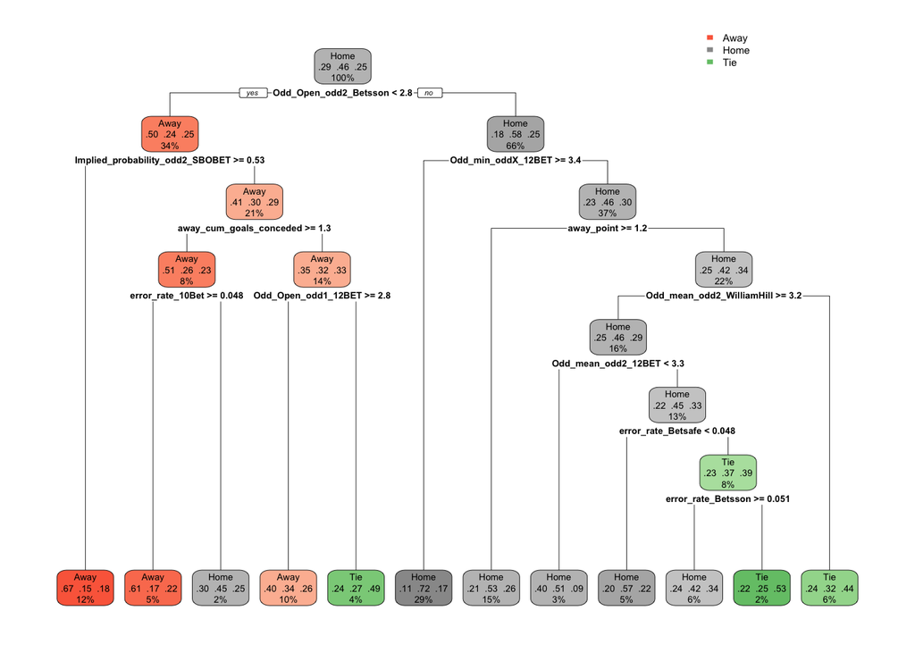

```r
setwd("/Users/elifkonyar/Desktop/Proje Son")
league_matches_raw<- readRDS("df9b1196-e3cf-4cc7-9159-f236fe738215_matches.rds")



tablo<-fread("model_tablosu_after_rf.csv")
tablo<-tablo[,-1]



##PREDICTION-DECISION TREE----
tree_bu_sezon_rapor<-data.table()


tablo_this_year<-fread("tablo_this_year.csv")
tablo_this_year<-tablo_this_year[order(Match_Date)]
tablo_this_year_result<-tablo_this_year[,c("matchId","Match_Result")]
tablo_this_year<-tablo_this_year[,-1]


tablo_this_year_matchID<-tablo_this_year$matchId
tablo_this_year<-tablo_this_year[,c(-1,-2,-3)]

desired_cols<-colnames(tablo)
tablo_this_year2<-tablo_this_year[,desired_cols,with=FALSE]



cp_param<-0.004
minbucket_param<-60
#omitting match id, league id and match date
predict_tree=rpart(Match_Result~., tablo,control=rpart.control(cp=cp_param,minbucket = minbucket_param))
rpart.plot(predict_tree)
```

Then, using the tree above, the average rps value for each week is calculated for the season 2018-2019. The code below calculates average rps values for each week.

```r
predict_leaf<-rpart.predict.leaves(predict_tree, tablo_this_year, type = "where")
frame<-as.data.table(predict_tree$frame)
test_predict<-as.data.table(predict(predict_tree,tablo_this_year))
test_predict$games_in_its_leaf<-0
test_predict$which_leaf<--1
predict_leaf[[1]]
```

```
## [1] 9
```

```r
for(i in 1:length(tablo_this_year$Match_Result)){
  tmp<-predict_leaf[[i]]
  test_predict[i,5]<-tmp
  test_predict[i,4]<-frame[[tmp,2]]
}




tablo_this_year_matchID<-as.data.table(tablo_this_year_matchID)
tablo_this_year_matchID<-left_join(tablo_this_year_matchID,league_matches_raw,by=c("tablo_this_year_matchID"="matchId"))
tablo_this_year_matchID<-tablo_this_year_matchID[,c(1,3,4)]
tablo_this_year_matchID<-as.data.table(tablo_this_year_matchID)
tablo_this_year_matchID[,Real_result:=tablo_this_year_result$Match_Result]

frame<-as.data.table(predict_tree$frame)



report<-paste0(tablo_this_year_matchID[1,1], ",",test_predict[1,2],",",test_predict[1,3],",",test_predict[1,1])


for(i in 2:nrow(tablo_this_year_matchID)){
  report<-paste0(report,",",tablo_this_year_matchID[i,1], ",",test_predict[i,2],",",test_predict[i,3],",",test_predict[i,1])
}


###rps calculation
test_predict[,pred_id:=1:.N]
test_predict[,Predictions:=ifelse(Away>Home & Away>Tie, 1, ifelse(Tie>Home &Tie>Away,3,2))]
test_predict[,Real:=tablo_this_year_matchID$Real_result]
outcome_for_rps=data.table::dcast(test_predict,pred_id~Real,value.var='pred_id')
outcome_for_rps[,pred_id:=NULL]
outcome_for_rps[is.na(outcome_for_rps)]=0
outcome_for_rps[outcome_for_rps>0]=1
colnames(outcome_for_rps)[1]<-"Away_res"
colnames(outcome_for_rps)[2]<-"Home_res"
colnames(outcome_for_rps)[3]<-"Tie_res"
setcolorder(outcome_for_rps,c('Home_res','Tie_res','Away_res'))

outcome_for_rps[,Tie_res:=ifelse(Home_res==1,1,Tie_res)]
outcome_for_rps[,Away_res:=ifelse(Tie_res==1,1,Away_res)]

#prediction probabilities
test_predict<-cbind(test_predict,outcome_for_rps)
cvresult_probs<-apply(test_predict[,c("Home","Tie","Away")],1,cumsum)
cvresult_probs<-as.data.table(t(cvresult_probs))
#calculation of RPS
rps<-((cvresult_probs$Home-outcome_for_rps$Home_res)^2 +
        (cvresult_probs$Away-outcome_for_rps$Away_res)^2 +
        (cvresult_probs$Tie-outcome_for_rps$Tie_res)^2)/2

rps<-as.data.table(rps)
cvresult<-cbind(test_predict,rps)
cvresult[,home_name:=tablo_this_year_matchID$home]
cvresult[,away_name:=tablo_this_year_matchID$away]

tree_bu_sezon_rapor<-rbind(tree_bu_sezon_rapor,data.table(cp=predict_tree$control$cp,minbucket=predict_tree$control$minbucket,rps=mean(cvresult$rps)))
cvresult<-cvresult[,-c("pred_id")]
cvresult<-cvresult[,-c("Home_res","Tie_res","Away_res")]

tablo_this_year_result<-rbind(tablo_this_year_result,data.table(matchId="city-liver",Match_Result="Home"))
cvresult<-rbind(cvresult,data.table(Away=0.1040609,Home=0.7119289,Tie=0.1840102,games_in_its_leaf=757,
                                    which_leaf=29,Predictions=2,Real="Home",rps=0.04690681,home_name="manchester-city",away_name="liverpool"))

focused<-cbind(cvresult,tablo_this_year_result$matchId)


week<-rep(0,50)
for(i in 1:8){
  week<-c(week,rep(i,10))
}
focused<-cbind(focused,week)

#tree performance every week
week_rps<-focused[,.(RPS=mean(rps),COUNT=.N),keyby=.(week)]

summary<-cvresult[,.(MEAN=mean(rps),COUNT=.N),keyby=.(games_in_its_leaf)]
```

The table below shows the average rps value for each week. Note that week 0 in the table represents the matches that are played before our prediction contest starts. Although the competition started in the 14th week, only 50 games are shown in the table. It seems that the data related to the 2018-2019 season does not consist of the first four weeks information. Additionally, the first five weeks’ information is ignored to obtain match related statistics. In this way, we do not need to handle with any missing information.

```r
setnames(week_rps,old="RPS",new = "MEAN_RPS")
knitr::kable(week_rps)
```

| week | MEAN_RPS | COUNT |
| --- | --- | --- |
| 0 | 0.1807835 | 50 |
| 1 | 0.1606307 | 10 |
| 2 | 0.1747219 | 10 |
| 3 | 0.1732242 | 10 |
| 4 | 0.1475662 | 10 |
| 5 | 0.2732234 | 10 |
| 6 | 0.2227850 | 10 |
| 7 | 0.2332347 | 10 |
| 8 | 0.2147251 | 10 |

Then, to understand under what circumstances the performance of constructed tree becomes worse, we analyzed the rps values for the season 2018-2019 further. We grouped the 2018-2019 games according to the leaf nodes they have fallen. By analyzing this, we managed to gain a better insight into the model. The analysis will be illustrated by using the table below.

```r
setnames(summary,old="MEAN",new = "MEAN_RPS")
knitr::kable(summary)
```

| games_in_its_leaf | MEAN_RPS | COUNT |
| --- | --- | --- |
| 64 | 0.2623535 | 10 |
| 65 | 0.2370809 | 3 |
| 106 | 0.2690103 | 5 |
| 122 | 0.2363192 | 16 |
| 161 | 0.2685082 | 7 |
| 250 | 0.2309131 | 14 |
| 322 | 0.1261660 | 20 |
| 390 | 0.1883892 | 13 |
| 757 | 0.1546340 | 42 |

First of all, each row of the table below represents a leaf node of the constructed decision tree. From the first row of the table, we can conclude that 10 matches in the season 2018 - 2019 located in a specific leaf node. Furthermore, during the training process of the tree, 64 matches have fallen into that leaf node. Finally, the average rps value for this leaf node is calculated as 0.2623. On the other hand, as we can see from the last row of the table, 42 matches have fallen into in another specific leaf node constructed with 757 matches. Finally, the average rps value for this leaf node is calculated as 0.1546. Under the light of these explanations, we can conclude that, while some leaf nodes are exceptionally good at predicting the outcome accurately, others are really bad. (Before proceeding the next step, we need to emphasize that MEAN_RPS value for first and last row is calculated by considering the 10 and 42 matches respectively in the season 2018-2019. However, we think that if we had conducted this analysis during the cross-validation stage, the leaf nodes that predict the outcome correctly would be the same leaf nodes)

Then, beside of predicting probabilities of outcomes, we employed the constructed tree as a clustering tool. If a match falls into a leaf node that is likely to predict the outcome correctly, the probability of outcomes for the game remained as predicted. Otherwise, we conclude that tree is not capable of predicting the outcome of the game perfectly, and the probability of outcomes for the game is predicted via other learning approaches. Approaches such as gradient boosting, random forest and logistic regression are utilized one more time at this step. The lowest average rps value is obtained via lasso logistic regression.

## 2.5) Model Construction 2

As a result of the analysis in the previous part, we decided that two leaf nodes that have 757 and 322 games_in_its_leaf are good at predicting the outcome. For the other leaf nodes, it is not reasonable to claim the existence of learning. Therefore, probabilities for the matches that have fallen into other leaf nodes are calculated via logistic regression.

The code below detects the matches that are likely to be predicted inaccurately, and it calculates the interested probabilities via lasso logistic regression.

```r
setwd("/Users/elifkonyar/Desktop/Proje Son")
leafs<-c(322,757)


focused_tree<-focused[games_in_its_leaf %in% leafs]

focused_other<-focused[!games_in_its_leaf %in% leafs]
focused_other_ID<-focused_other$V2



#new method for other matches
##PREDICTION-Logistic----
tree_bu_sezon_rapor<-data.table()


tablo_this_year<-fread("tablo_this_year.csv")
tablo_this_year<-tablo_this_year[matchId %in% focused_other_ID]
tablo_this_year_result<-tablo_this_year[,c("matchId","Match_Result")]
tablo_this_year<-tablo_this_year[,-1]


tablo_this_year_matchID<-tablo_this_year$matchId
tablo_this_year<-tablo_this_year[,c(-1,-2,-3)]

desired_cols<-colnames(tablo)
tablo_this_year2<-tablo_this_year[,desired_cols,with=FALSE]


train_features<-tablo
train_features_matchresult<-as.data.table(train_features$Match_Result)
train_features<-train_features[,-c("Match_Result")]
train_features<-as.data.table(train_features)
train_features<-cbind(train_features_matchresult,train_features)
setnames(train_features,old="V1",new="Match_Result")



not_included_feature_indices="Match_Result"
alpha=1
nlambda=50
tune_lambda=TRUE
nofReplications=1
nFolds=10
trace=T

set.seed(1)
glm_features=train_features[complete.cases(train_features)]
train_class=glm_features$Match_Result
glm_train_data=glm_features[,-not_included_feature_indices,with=F]
glmnet_alldata = glmnet(as.matrix(glm_train_data), as.factor(train_class), family="multinomial", alpha = alpha, nlambda=nlambda,standardize = TRUE)
lambda_sequence = glmnet_alldata$lambda
valid_pred = predict(glmnet_alldata, data.matrix(tablo_this_year2[,-"Match_Result"]), s=lambda_sequence[14], type = "response")
test_predict<-as.data.table(valid_pred[,,1])



tablo_this_year_matchID<-as.data.table(tablo_this_year_matchID)
tablo_this_year_matchID<-left_join(tablo_this_year_matchID,league_matches_raw,by=c("tablo_this_year_matchID"="matchId"))
tablo_this_year_matchID<-tablo_this_year_matchID[,c(1,3,4)]
tablo_this_year_matchID<-as.data.table(tablo_this_year_matchID)
tablo_this_year_matchID[,Real_result:=tablo_this_year_result$Match_Result]


report<-paste0(tablo_this_year_matchID[1,1], ",",test_predict[1,2],",",test_predict[1,3],",",test_predict[1,1])


for(i in 2:nrow(tablo_this_year_matchID)){
  report<-paste0(report,",",tablo_this_year_matchID[i,1], ",",test_predict[i,2],",",test_predict[i,3],",",test_predict[i,1])
}


###rps calculation
test_predict[,pred_id:=1:.N]
test_predict[,Predictions:=ifelse(Away>Home & Away>Tie, 1, ifelse(Tie>Home &Tie>Away,3,2))]
test_predict[,Real:=tablo_this_year_matchID$Real_result]
outcome_for_rps=data.table::dcast(test_predict,pred_id~Real,value.var='pred_id')
outcome_for_rps[,pred_id:=NULL]
outcome_for_rps[is.na(outcome_for_rps)]=0
outcome_for_rps[outcome_for_rps>0]=1
colnames(outcome_for_rps)[1]<-"Away_res"
colnames(outcome_for_rps)[2]<-"Home_res"
colnames(outcome_for_rps)[3]<-"Tie_res"
setcolorder(outcome_for_rps,c('Home_res','Tie_res','Away_res'))

outcome_for_rps[,Tie_res:=ifelse(Home_res==1,1,Tie_res)]
outcome_for_rps[,Away_res:=ifelse(Tie_res==1,1,Away_res)]

#prediction probabilities
test_predict<-cbind(test_predict,outcome_for_rps)
cvresult_probs<-apply(test_predict[,c("Home","Tie","Away")],1,cumsum)
cvresult_probs<-as.data.table(t(cvresult_probs))
#calculation of RPS
rps<-((cvresult_probs$Home-outcome_for_rps$Home_res)^2 +
        (cvresult_probs$Away-outcome_for_rps$Away_res)^2 +
        (cvresult_probs$Tie-outcome_for_rps$Tie_res)^2)/2

rps<-as.data.table(rps)
cvresult<-cbind(test_predict,rps)
cvresult[,home_name:=tablo_this_year_matchID$home]
cvresult[,away_name:=tablo_this_year_matchID$away]

cvresult<-cvresult[,-c("pred_id")]
cvresult<-cvresult[,-c("Home_res","Tie_res","Away_res")]
cvresult<-cvresult[order(home_name,away_name)]
focused_other<-focused_other[order(home_name,away_name)]
cvresult<-cbind(cvresult,focused_other$week)


tree_logistic<-focused_tree[,.(Away,Home,Tie,Real,rps,home_name,away_name,week)]
log_cv<-cvresult[,.(Away,Home,Tie,Real,rps,home_name,away_name,week=V2)]
tree_logistic<-rbind(tree_logistic,log_cv)
combined_week_rps_tree_logistic_after_rf<-tree_logistic[,.(RPS=mean(rps),COUNT=.N),keyby=.(week)]
```

```r
setnames(combined_week_rps_tree_logistic_after_rf,old="RPS",new = "MEAN_RPS")
knitr::kable(combined_week_rps_tree_logistic_after_rf)
```

| week | MEAN_RPS | COUNT |
| --- | --- | --- |
| 0 | 0.1756247 | 50 |
| 1 | 0.1759857 | 10 |
| 2 | 0.1712256 | 10 |
| 3 | 0.1861945 | 10 |
| 4 | 0.1622564 | 10 |
| 5 | 0.2612520 | 10 |
| 6 | 0.1922740 | 10 |
| 7 | 0.2534801 | 10 |
| 8 | 0.1911948 | 10 |

# 3) Conclusion

The comparison between Decision Tree and Decision Tree + Lasso Logistic Regression models can be seen below. In 8 weeks period, using ensemble model of the decision tree and logistic regression improved the average rps value from 0.2000139 to 0.1992329. In 13 weeks period, the mean rps value is also decreased by using the ensemble model. Therefore, as expected, the ensemble model performed better than a single model.

```r
knitr::kable(final_summary)
```

| Method | Matches | AVG_RPS |
| --- | --- | --- |
| Tree | 13 weeks | 0.1926176 |
| Tree | 8 weeks | 0.2000139 |
| Tree+Logistic | 13 weeks | 0.1901528 |
| Tree+Logistic | 8 weeks | 0.1992329 |

# 4) Future Work

First of all, additional match-related features can be further improved. We obtained the cumulative number of goals conceded by the away team in this season in all matches, the cumulative number of goals scored by the home team in this season in all matches and so on. These features can also be divided into 2 categories such that the statistics of the home team can be obtained from the previous home matches and from the previous away matches seperately. The same procedure can be applied to the away team, as well. This may improve the performance of the models.

# 5) References

[1] Jonas Mirza and Niklas Fejes,2016, “Statistical Football Modeling A Study of Football Betting and Implementation of Statistical Algorithms in Premier League”, available online: http://www.it.uu.se/edu/course/homepage/projektTDB/ht15/project16/Project16_Report.pdf

[2] Leo Breiman, 2001, “Random Forests” Machine Learning, 45, 5-32

[3] Lecture Notes